# Homework Assignment 1

Naman Gupta

Assigned: Oct 24, 2020, Due Sun Nov 01, 2020 11:59PM

## HW-1 Instructions

> Our class emphasizes clear communication of data analysis results to non-technical audiences. I expect your HTML output documents to be readable and well formatted. I expect you to put ample comments in your R code to make the code understandable. Along with accuracy of results, I am looking for quality of presentation as well. This homework is due by **11:59PM on Nov 01st**. To complete this assignment, follow these steps:
1. Create a new RStudio Project for this HW. Sync the project directory with a GitHub Repository (see instructions on Canvas on how to do that).
2. Download the `HW1.Rmd` file from Canvas. Save the file in the RStudio Project Directory.
3. Open `HW1.Rmd` in RStudio. Replace the “Your Name Here” text in the `author:` field with your name.
4. Supply your solutions to the homework by editing `HW1.Rmd`.
5. Run your code in the Console and Knit HTML frequently to check for errors.
6. You may find it easier to solve a problem by interacting only with the Console at first.
7. When you have completed the homework please check that your knits correctly when you click `Knit HTML`.
8. “Push” all your local changes to the GitHub Repo for the project.
9. Submit your RMD file, the HTML output and a link to your GitHub Repo on Canvas.

## Data frame basics

We will continue working with the nycflights dataset we looked at in class. **Please be sure to keep the data file in the same directory as the RMD file - your project directory.**

First - make sure that you are reading the data correctly and doing all the data cleaning steps that we did in class. Feel free to go beyond our class work in cleaning the data if you feel the need.

I now would like you to answer the following - all in their own separate R code blocks.

```r
# Using read.csv for reading the CSV file
nyc <- read.csv("nycflights.csv")

# Now we will explore this data
str(nyc)
```

```
## 'data.frame':    336776 obs. of  20 variables:
##  $ X             : int  1 2 3 4 5 6 7 8 9 10 ...
##  $ year          : int  2013 2013 2013 2013 2013 2013 2013 2013 2013 2013 ...
##  $ month         : int  1 1 1 1 1 1 1 1 1 1 ...
##  $ day           : int  1 1 1 1 1 1 1 1 1 1 ...
##  $ dep_time      : int  517 533 542 544 554 554 555 557 557 558 ...
##  $ sched_dep_time: int  515 529 540 545 600 558 600 600 600 600 ...
##  $ dep_delay     : int  2 4 2 -1 -6 -4 -5 -3 -3 -2 ...
##  $ arr_time      : int  830 850 923 1004 812 740 913 709 838 753 ...
##  $ sched_arr_time: int  819 830 850 1022 837 728 854 723 846 745 ...
##  $ arr_delay     : int  11 20 33 -18 -25 12 19 -14 -8 8 ...
##  $ carrier       : Factor w/ 16 levels "9E","AA","AS",..: 12 12 2 4 5 12 4 6 4 2 ...
##  $ flight        : int  1545 1714 1141 725 461 1696 507 5708 79 301 ...
##  $ tailnum       : Factor w/ 4043 levels "D942DN","N0EGMQ",..: 180 524 2401 3204 2661 1142 1829 3300 2207 1178 ...
##  $ origin        : Factor w/ 3 levels "EWR","JFK","LGA": 1 3 2 2 3 1 1 3 2 3 ...
##  $ dest          : Factor w/ 105 levels "ABQ","ACK","ALB",..: 44 44 59 13 5 70 36 43 55 70 ...
##  $ air_time      : int  227 227 160 183 116 150 158 53 140 138 ...
##  $ distance      : int  1400 1416 1089 1576 762 719 1065 229 944 733 ...
##  $ hour          : int  5 5 5 5 6 5 6 6 6 6 ...
##  $ minute        : int  15 29 40 45 0 58 0 0 0 0 ...
##  $ time_hour     : Factor w/ 6936 levels "2013-01-01 05:00:00",..: 1 1 1 1 2 1 2 2 2 2 ...
```

```r
head(nyc)
```

```
##   X year month day dep_time sched_dep_time dep_delay arr_time sched_arr_time
## 1 1 2013     1   1      517            515         2      830            819
## 2 2 2013     1   1      533            529         4      850            830
## 3 3 2013     1   1      542            540         2      923            850
## 4 4 2013     1   1      544            545        -1     1004           1022
## 5 5 2013     1   1      554            600        -6      812            837
## 6 6 2013     1   1      554            558        -4      740            728
##   arr_delay carrier flight tailnum origin dest air_time distance hour minute
## 1        11      UA   1545  N14228    EWR  IAH      227     1400    5     15
## 2        20      UA   1714  N24211    LGA  IAH      227     1416    5     29
## 3        33      AA   1141  N619AA    JFK  MIA      160     1089    5     40
## 4       -18      B6    725  N804JB    JFK  BQN      183     1576    5     45
## 5       -25      DL    461  N668DN    LGA  ATL      116      762    6      0
## 6        12      UA   1696  N39463    EWR  ORD      150      719    5     58
##             time_hour
## 1 2013-01-01 05:00:00
## 2 2013-01-01 05:00:00
## 3 2013-01-01 05:00:00
## 4 2013-01-01 05:00:00
## 5 2013-01-01 06:00:00
## 6 2013-01-01 05:00:00
```

```r
tail(nyc)
```

```
##             X year month day dep_time sched_dep_time dep_delay arr_time
## 336771 336771 2013     9  30       NA           1842        NA       NA
## 336772 336772 2013     9  30       NA           1455        NA       NA
## 336773 336773 2013     9  30       NA           2200        NA       NA
## 336774 336774 2013     9  30       NA           1210        NA       NA
## 336775 336775 2013     9  30       NA           1159        NA       NA
## 336776 336776 2013     9  30       NA            840        NA       NA
##        sched_arr_time arr_delay carrier flight tailnum origin dest air_time
## 336771           2019        NA      EV   5274  N740EV    LGA  BNA       NA
## 336772           1634        NA      9E   3393    <NA>    JFK  DCA       NA
## 336773           2312        NA      9E   3525    <NA>    LGA  SYR       NA
## 336774           1330        NA      MQ   3461  N535MQ    LGA  BNA       NA
## 336775           1344        NA      MQ   3572  N511MQ    LGA  CLE       NA
## 336776           1020        NA      MQ   3531  N839MQ    LGA  RDU       NA
##        distance hour minute           time_hour
## 336771      764   18     42 2013-09-30 18:00:00
## 336772      213   14     55 2013-09-30 14:00:00
## 336773      198   22      0 2013-09-30 22:00:00
## 336774      764   12     10 2013-09-30 12:00:00
## 336775      419   11     59 2013-09-30 11:00:00
## 336776      431    8     40 2013-09-30 08:00:00
```

```r
summary(nyc)
```

```
##        X               year          month             day
##  Min.   :     1   Min.   :2013   Min.   : 1.000   Min.   : 1.00
##  1st Qu.: 84195   1st Qu.:2013   1st Qu.: 4.000   1st Qu.: 8.00
##  Median :168388   Median :2013   Median : 7.000   Median :16.00
##  Mean   :168388   Mean   :2013   Mean   : 6.549   Mean   :15.71
##  3rd Qu.:252582   3rd Qu.:2013   3rd Qu.:10.000   3rd Qu.:23.00
##  Max.   :336776   Max.   :2013   Max.   :12.000   Max.   :31.00
##
##     dep_time    sched_dep_time   dep_delay          arr_time    sched_arr_time
##  Min.   :   1   Min.   : 106   Min.   : -43.00   Min.   :   1   Min.   :   1
##  1st Qu.: 907   1st Qu.: 906   1st Qu.:  -5.00   1st Qu.:1104   1st Qu.:1124
##  Median :1401   Median :1359   Median :  -2.00   Median :1535   Median :1556
##  Mean   :1349   Mean   :1344   Mean   :  12.64   Mean   :1502   Mean   :1536
##  3rd Qu.:1744   3rd Qu.:1729   3rd Qu.:  11.00   3rd Qu.:1940   3rd Qu.:1945
##  Max.   :2400   Max.   :2359   Max.   :1301.00   Max.   :2400   Max.   :2359
##  NA's   :8255                  NA's   :8255      NA's   :8713
##    arr_delay           carrier          flight        tailnum
##  Min.   : -86.000   UA     :58665   Min.   :   1   N725MQ :   575
##  1st Qu.: -17.000   B6     :54635   1st Qu.: 553   N722MQ :   513
##  Median :  -5.000   EV     :54173   Median :1496   N723MQ :   507
##  Mean   :   6.895   DL     :48110   Mean   :1972   N711MQ :   486
##  3rd Qu.:  14.000   AA     :32729   3rd Qu.:3465   N713MQ :   483
##  Max.   :1272.000   MQ     :26397   Max.   :8500   (Other):331700
##  NA's   :9430       (Other):62067                  NA's   :  2512
##  origin            dest           air_time        distance         hour
##  EWR:120835   ORD    : 17283   Min.   : 20.0   Min.   :  17   Min.   : 1.00
##  JFK:111279   ATL    : 17215   1st Qu.: 82.0   1st Qu.: 502   1st Qu.: 9.00
##  LGA:104662   LAX    : 16174   Median :129.0   Median : 872   Median :13.00
##               BOS    : 15508   Mean   :150.7   Mean   :1040   Mean   :13.18
##               MCO    : 14082   3rd Qu.:192.0   3rd Qu.:1389   3rd Qu.:17.00
##               CLT    : 14064   Max.   :695.0   Max.   :4983   Max.   :23.00
##               (Other):242450   NA's   :9430
##      minute                    time_hour
##  Min.   : 0.00   2013-09-13 08:00:00:    94
##  1st Qu.: 8.00   2013-09-20 08:00:00:    94
##  Median :29.00   2013-09-09 08:00:00:    93
##  Mean   :26.23   2013-09-16 08:00:00:    93
##  3rd Qu.:44.00   2013-09-23 08:00:00:    93
##  Max.   :59.00   2013-09-19 08:00:00:    92
##                  (Other)            :336217
```

```r
# Delete the column named "X"
nyc$X <- NULL

# Recode columns as factors as needed
nyc$carrier <- as.factor(nyc$carrier)
nyc$flight <- as.factor(nyc$flight)
nyc$tailnum <- as.factor(nyc$tailnum)
nyc$origin <- as.factor(nyc$origin)
nyc$dest <- as.factor(nyc$dest)

# Re-check summary and str
str(nyc)
```

```
## 'data.frame':    336776 obs. of  19 variables:
##  $ year          : int  2013 2013 2013 2013 2013 2013 2013 2013 2013 2013 ...
##  $ month         : int  1 1 1 1 1 1 1 1 1 1 ...
##  $ day           : int  1 1 1 1 1 1 1 1 1 1 ...
##  $ dep_time      : int  517 533 542 544 554 554 555 557 557 558 ...
##  $ sched_dep_time: int  515 529 540 545 600 558 600 600 600 600 ...
##  $ dep_delay     : int  2 4 2 -1 -6 -4 -5 -3 -3 -2 ...
##  $ arr_time      : int  830 850 923 1004 812 740 913 709 838 753 ...
##  $ sched_arr_time: int  819 830 850 1022 837 728 854 723 846 745 ...
##  $ arr_delay     : int  11 20 33 -18 -25 12 19 -14 -8 8 ...
##  $ carrier       : Factor w/ 16 levels "9E","AA","AS",..: 12 12 2 4 5 12 4 6 4 2 ...
##  $ flight        : Factor w/ 3844 levels "1","2","3","4",..: 1382 1545 1042 677 425 1527 469 3700 69 266 ...
##  $ tailnum       : Factor w/ 4043 levels "D942DN","N0EGMQ",..: 180 524 2401 3204 2661 1142 1829 3300 2207 1178 ...
##  $ origin        : Factor w/ 3 levels "EWR","JFK","LGA": 1 3 2 2 3 1 1 3 2 3 ...
##  $ dest          : Factor w/ 105 levels "ABQ","ACK","ALB",..: 44 44 59 13 5 70 36 43 55 70 ...
##  $ air_time      : int  227 227 160 183 116 150 158 53 140 138 ...
##  $ distance      : int  1400 1416 1089 1576 762 719 1065 229 944 733 ...
##  $ hour          : int  5 5 5 5 6 5 6 6 6 6 ...
##  $ minute        : int  15 29 40 45 0 58 0 0 0 0 ...
##  $ time_hour     : Factor w/ 6936 levels "2013-01-01 05:00:00",..: 1 1 1 1 2 1 2 2 2 2 ...
```

```r
summary(nyc)
```

```
##       year          month             day           dep_time    sched_dep_time
##  Min.   :2013   Min.   : 1.000   Min.   : 1.00   Min.   :   1   Min.   : 106
##  1st Qu.:2013   1st Qu.: 4.000   1st Qu.: 8.00   1st Qu.: 907   1st Qu.: 906
##  Median :2013   Median : 7.000   Median :16.00   Median :1401   Median :1359
##  Mean   :2013   Mean   : 6.549   Mean   :15.71   Mean   :1349   Mean   :1344
##  3rd Qu.:2013   3rd Qu.:10.000   3rd Qu.:23.00   3rd Qu.:1744   3rd Qu.:1729
##  Max.   :2013   Max.   :12.000   Max.   :31.00   Max.   :2400   Max.   :2359
##                                                  NA's   :8255
##    dep_delay          arr_time    sched_arr_time   arr_delay
##  Min.   : -43.00   Min.   :   1   Min.   :   1   Min.   : -86.000
##  1st Qu.:  -5.00   1st Qu.:1104   1st Qu.:1124   1st Qu.: -17.000
##  Median :  -2.00   Median :1535   Median :1556   Median :  -5.000
##  Mean   :  12.64   Mean   :1502   Mean   :1536   Mean   :   6.895
##  3rd Qu.:  11.00   3rd Qu.:1940   3rd Qu.:1945   3rd Qu.:  14.000
##  Max.   :1301.00   Max.   :2400   Max.   :2359   Max.   :1272.000
##  NA's   :8255      NA's   :8713                  NA's   :9430
##     carrier          flight          tailnum       origin
##  UA     :58665   15     :   968   N725MQ :   575   EWR:120835
##  B6     :54635   27     :   898   N722MQ :   513   JFK:111279
##  EV     :54173   181    :   882   N723MQ :   507   LGA:104662
##  DL     :48110   301    :   871   N711MQ :   486
##  AA     :32729   161    :   786   N713MQ :   483
##  MQ     :26397   695    :   782   (Other):331700
##  (Other):62067   (Other):331589   NA's   :  2512
##       dest           air_time        distance         hour
##  ORD    : 17283   Min.   : 20.0   Min.   :  17   Min.   : 1.00
##  ATL    : 17215   1st Qu.: 82.0   1st Qu.: 502   1st Qu.: 9.00
##  LAX    : 16174   Median :129.0   Median : 872   Median :13.00
##  BOS    : 15508   Mean   :150.7   Mean   :1040   Mean   :13.18
##  MCO    : 14082   3rd Qu.:192.0   3rd Qu.:1389   3rd Qu.:17.00
##  CLT    : 14064   Max.   :695.0   Max.   :4983   Max.   :23.00
##  (Other):242450   NA's   :9430
##      minute                    time_hour
##  Min.   : 0.00   2013-09-13 08:00:00:    94
##  1st Qu.: 8.00   2013-09-20 08:00:00:    94
##  Median :29.00   2013-09-09 08:00:00:    93
##  Mean   :26.23   2013-09-16 08:00:00:    93
##  3rd Qu.:44.00   2013-09-23 08:00:00:    93
##  Max.   :59.00   2013-09-19 08:00:00:    92
##                  (Other)            :336217
```

### Data Exploration

Let’s first do some simple exploration of this data. I would like for you to answer each of the questions below with an **inline R code** integrated into the text and not in a separate R code block.

- How many airlines are there? (Hint: `levels` and `length` can be useful here)

```r
numairlines <- length(levels(nyc$carrier))
```

There are 16 airlines.

- How many flights there were by the airline with code `OO`? (Hint: `nrow` can be useful here along with logical indexing)

```r
numflightsOO <- nrow(nyc[nyc$carrier == "OO",])
```

There are 32 flights by the airline code 00.

- How long is the shortest flight out of any NYC airport? (Hint: `min` can be useful, remember to handle `NA` values)

```r
shortestflight <- min(nyc$air_time, na.rm = TRUE)
```

- How many flights where there by United Airlines (code: UA) on Jan 12th 2013?

```r
numflightsUA <- nrow(nyc[nyc$month == 1 & nyc$day == 12 & nyc$carrier == "UA",])
```

There were 112 by United Airlines on Jan 12th 2013.

### Arrival Delay

Lets focus on Arrival Delay.

- What was the average arrival delay for all airports and all airlines combined in Jan 2013?

```r
avgarrdelay <- mean(nyc$arr_delay, na.rm = TRUE)
```

- Whats was the median arrival delay for all airports and all airlines combined in Jan 2013?

```r
medianarrdelay <- median(nyc$arr_delay, na.rm = TRUE)
```

Based on your answers to the two questions above, what can you say about the distribution of arrival delays? Provide your answer in a text paragraph form.

### Airline Performance

Lets see if all airlines are equally terrible as far as flight arrival delays are concerned. For this question you will have to make sure that airline column is coded as a factor.

- Calculate average arrival delays by airline (Hint: look up the command `tapply`)

```r
# Use function tapply
arr_delay_by_airline <- round(tapply(nyc$arr_delay, nyc$carrier, mean, na.rm = TRUE),2)
arr_delay_by_airline
```

```
##    9E    AA    AS    B6    DL    EV    F9    FL    HA    MQ    OO    UA    US
##  7.38  0.36 -9.93  9.46  1.64 15.80 21.92 20.12 -6.92 10.77 11.93  3.56  2.13
##    VX    WN    YV
##  1.76  9.65 15.56
```

- Draw a Bar Plot of Average Arrival Delays for all the Airlines (Hint: command for making a Bar Plot is simply `barplot`)

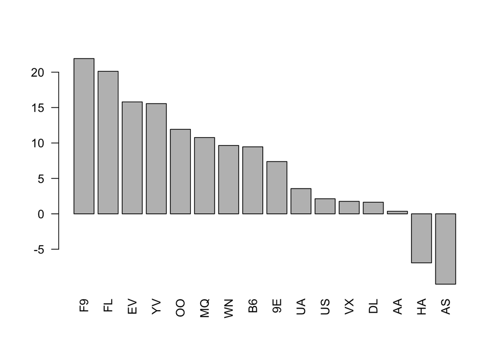

```r
barplot(sort(arr_delay_by_airline, decreasing = TRUE), las = 2)
```

- Which airline has the highest average arrival delay? Which airline has the smallest average arrival delay? Are there airlines that actually have negative average delay? Provide answer to this question in a text paragraph form using **inline R code**.

```r
max_delay_airline <- names(arr_delay_by_airline[arr_delay_by_airline == max(arr_delay_by_airline)])

min_delay_airline <- names(arr_delay_by_airline[arr_delay_by_airline == min(arr_delay_by_airline)])

neg_delay_airline <- names(arr_delay_by_airline[arr_delay_by_airline < 0])
```

The airline with the highest average arrival delay is F9.

The airline with the smallest average arrival delay is AS.

The airlines with negative average arrival delays are AS, HA.

### Air Gain

Create a new column named airgain such that airgain = (departure delay - arrival delay) : this is the amount of delay a flight made up while in air.

```r
nyc$airgain <- nyc$dep_delay - nyc$arr_delay
```

1. Explore airgain data - calculate suitable descriptive statistics and appropriate graphics to better understand this data. This part is open ended - you do what you feel works best for you.

```r
summary(nyc$airgain)
```

```
##    Min. 1st Qu.  Median    Mean 3rd Qu.    Max.    NA's
## -196.00   -3.00    7.00    5.66   17.00  109.00    9430
```

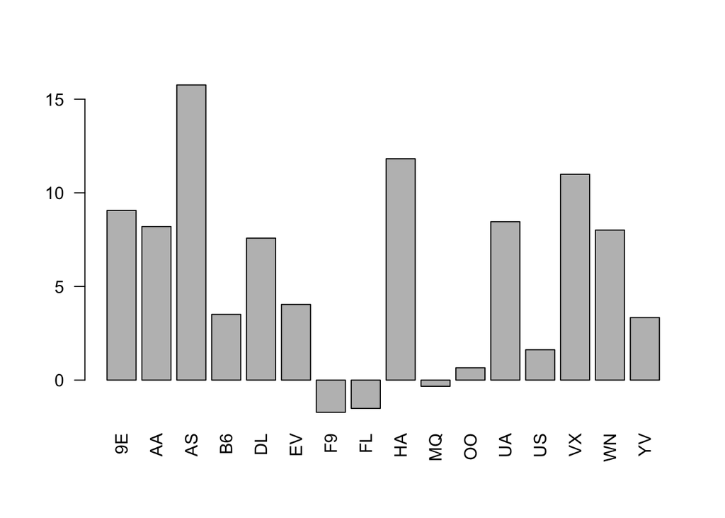

```r
#exploring airgain using tapply function
airgain_by_airline <- round(tapply(nyc$airgain, nyc$carrier, mean, na.rm = TRUE),2)
barplot(airgain_by_airline, las = 2)
```

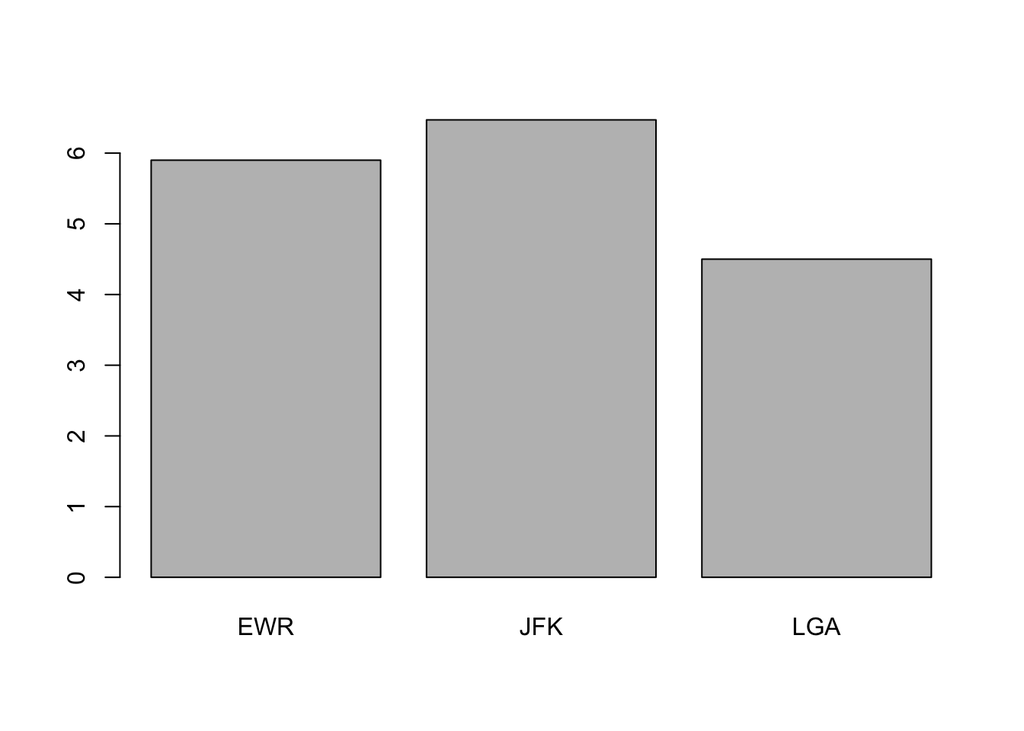

```r
airgain_by_origin_airport <- round(tapply(nyc$airgain, nyc$origin, mean, na.rm = TRUE),2)
barplot(airgain_by_origin_airport)
```

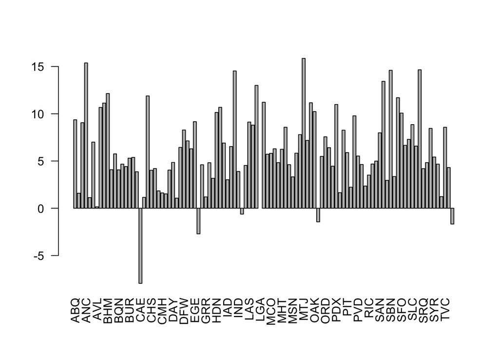

```r
airgain_by_dest_airport <- round(tapply(nyc$airgain, nyc$dest, mean, na.rm = TRUE),2)
barplot(airgain_by_dest_airport, las=2)
```

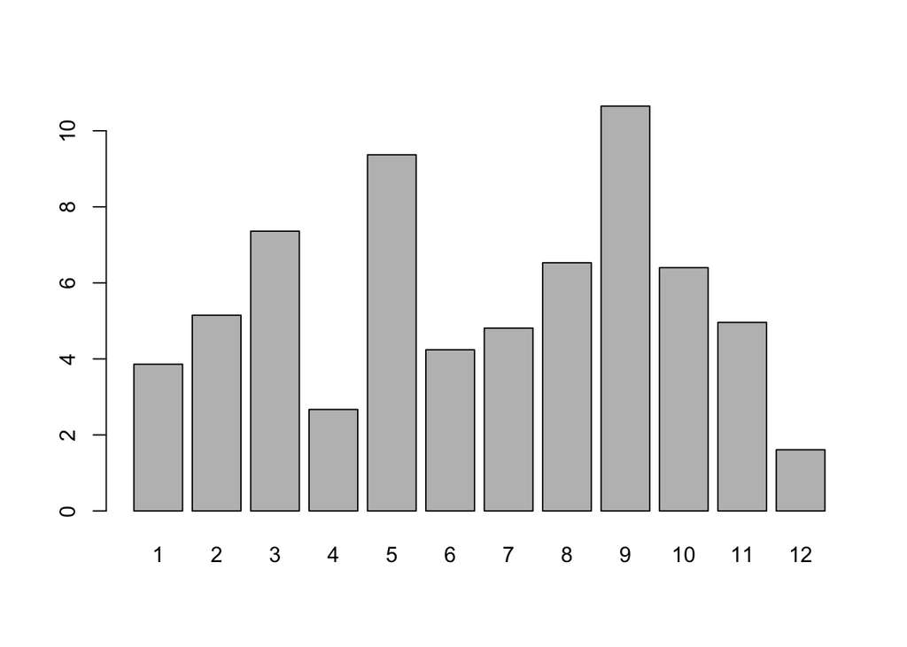

```r
airgain_by_month <- round(tapply(nyc$airgain, nyc$month, mean, na.rm = TRUE),2)
barplot(airgain_by_month)
```

2. Answer the questions:
- do airlines actually gain any time when in air on average?

> Yes. On average, there is a positive airgain.
- Calculate average airgain for different airlines - which airlines do a better job, which do a worse job?

```r
#calculated previously in airgain exploration
airgain_by_airline
```

```
##    9E    AA    AS    B6    DL    EV    F9    FL    HA    MQ    OO    UA    US
##  9.06  8.20 15.76  3.51  7.58  4.04 -1.72 -1.51 11.82 -0.33  0.66  8.46  1.62
##    VX    WN    YV
## 10.99  8.01  3.34
```

> AS and HA do a very good job in airgain. F9 and FL do particular poorly.
- Build a graphic of average airgain for different airlines sorted by airgain. We want to graphically visualize which airlines are good at “catching up” when in air and which airlines actually lose time further after taking off.

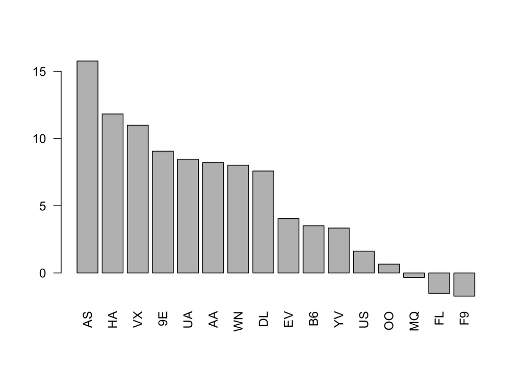

```r
#created previously in airgain exploration
barplot(sort(airgain_by_airline, decreasing = TRUE), las = 2)
```

That’s it. Once you are done, make sure everything works and knits well and then you can push your changes to the GitHub repo and uplaod the RMD flile and the html output to Canvas.

**Have Fun!**

Sanjeev